# Reproducible Research: Peer Assessment 1

Gary R Seamans

September 12, 2017

## Loading and preprocessing the data

The data used for this project can be downloaded from [Activity Data](https://d396qusza40orc.cloudfront.net/repdata%2Fdata%2Factivity.zip)

The data contains a header row. There are three columns: *steps*, *date*, *interval*.

1. **steps**: Number of steps taken in a 5-minute interval. Missing values are encoded as NA.
2. **date**: The date on which the measurement was taken in YYYY-MM-DD format
3. **interval**: Identifier for the 5-minute interval in which measurement was taken

The dataset is stored in a comma-separated-value (CSV) file and there are a total of 17,568 observations in this dataset.

### Load the libraries that I’ll be using:

1. **dplyr** for easier data manipulation
2. **lubridate** for date manipulations
3. **magrittr** for pipe operators
4. **knitr** for table generation with kable()
5. **ggplot2** for plotting
6. **mice** for imputing missing values
7. **grid** for nicely arrranging ggplots
8. **gridExtra** for nicely arranging ggplots
9. **strtable.R** for creating tables from str(). Thanks to **jbreyer** [strtable.R](https://gist.github.com/jbryer/4a0a5ab9fe7e1cf3be0e)

### Read in the data and take a look at the data.

```r
activities <- read.csv(file = "activity.csv")
kable(activities %>% sample_n(10), align = "l", row.names = FALSE)
```

| steps | date | interval |
| --- | --- | --- |
| 27 | 2012-10-23 | 710 |
| NA | 2012-11-01 | 1145 |
| 12 | 2012-11-27 | 1055 |
| 0 | 2012-10-18 | 1140 |
| 0 | 2012-10-03 | 2335 |
| 0 | 2012-11-12 | 2330 |
| 15 | 2012-11-11 | 1325 |
| 0 | 2012-10-30 | 2020 |
| 0 | 2012-11-23 | 2250 |
| 0 | 2012-11-17 | 1600 |

```r
source("strtable.R")
kable(strtable(activities))
```

| variable | class | levels | examples |
| --- | --- | --- | --- |
| steps | integer | NA | NA, NA, NA, NA, … |
| date | Factor w/ 61 levels | “2012-10-01”, “2012-10-02”, … | “2012-10-01”, … |
| interval | integer | NA | 0, 5, 10, 15, … |

**10 Sample Rows** below show data examples including the NA’s for steps

| steps | date | interval |
| --- | --- | --- |
| 36 | 2012-10-10 | 1755 |
| 0 | 2012-10-02 | 1300 |
| NA | 2012-11-04 | 1750 |
| 0 | 2012-11-07 | 2025 |
| 43 | 2012-10-05 | 725 |
| NA | 2012-10-01 | 1325 |
| 54 | 2012-11-19 | 645 |
| 0 | 2012-11-06 | 955 |
| 505 | 2012-10-27 | 830 |
| 503 | 2012-11-21 | 755 |

Printing the classes shows that dates are currtently factors. These will be changed to date types.

| variable | class | levels | examples |
| --- | --- | --- | --- |
| steps | integer | NA | NA, NA, NA, NA, … |
| date | Factor w/ 61 levels | “2012-10-01”, “2012-10-02”, … | “2012-10-01”, … |
| interval | integer | NA | 0, 5, 10, 15, … |

## What is the mean total number of steps taken per day?

For this part of the assignment, you can ignore the missing values in the dataset.

1. Calculate the total number of steps taken per day
2. If you do not understand the difference between a histogram and a barplot, research the difference between them. Make a histogram of the total number of steps taken each day
3. Calculate and report the mean and median of the total number of steps taken per day

As the first step I’ll remove the rows where steps = NA. Then I’ll calculate the steps per day, the historgram and the mean/median of the total number of steps taken per day. I thought that it might be interesting to calculate the total steps per weekday so I calculated that as well and added the weekdays to the dataset.

```r
activitiesNoNAs <- activities[complete.cases(activities),]
activitiesNoNAs %<>% mutate(date=ymd(date))
activitiesNoNAs$weekday <- as.factor(weekdays(activitiesNoNAs$date, abbreviate = TRUE))
stepsPerWeekDay <- aggregate(activitiesNoNAs$steps, by = list(activitiesNoNAs$weekday), sum)
stepsPerDay <- aggregate(activitiesNoNAs$steps, by = list(activitiesNoNAs$date), sum)
names(stepsPerWeekDay) <- c("Weekday", "Steps")
names(stepsPerDay) <- c("Day", "Steps")
kable(stepsPerDay[order(stepsPerDay$Day),], align = "l", row.names = FALSE)
```

| Day | Steps |
| --- | --- |
| 2012-10-02 | 126 |
| 2012-10-03 | 11352 |
| 2012-10-04 | 12116 |
| 2012-10-05 | 13294 |
| 2012-10-06 | 15420 |
| 2012-10-07 | 11015 |
| 2012-10-09 | 12811 |
| 2012-10-10 | 9900 |
| 2012-10-11 | 10304 |
| 2012-10-12 | 17382 |
| 2012-10-13 | 12426 |
| 2012-10-14 | 15098 |
| 2012-10-15 | 10139 |
| 2012-10-16 | 15084 |
| 2012-10-17 | 13452 |
| 2012-10-18 | 10056 |
| 2012-10-19 | 11829 |
| 2012-10-20 | 10395 |
| 2012-10-21 | 8821 |
| 2012-10-22 | 13460 |
| 2012-10-23 | 8918 |
| 2012-10-24 | 8355 |
| 2012-10-25 | 2492 |
| 2012-10-26 | 6778 |
| 2012-10-27 | 10119 |
| 2012-10-28 | 11458 |
| 2012-10-29 | 5018 |
| 2012-10-30 | 9819 |
| 2012-10-31 | 15414 |
| 2012-11-02 | 10600 |
| 2012-11-03 | 10571 |
| 2012-11-05 | 10439 |
| 2012-11-06 | 8334 |
| 2012-11-07 | 12883 |
| 2012-11-08 | 3219 |
| 2012-11-11 | 12608 |
| 2012-11-12 | 10765 |
| 2012-11-13 | 7336 |
| 2012-11-15 | 41 |
| 2012-11-16 | 5441 |
| 2012-11-17 | 14339 |
| 2012-11-18 | 15110 |
| 2012-11-19 | 8841 |
| 2012-11-20 | 4472 |
| 2012-11-21 | 12787 |
| 2012-11-22 | 20427 |
| 2012-11-23 | 21194 |
| 2012-11-24 | 14478 |
| 2012-11-25 | 11834 |
| 2012-11-26 | 11162 |
| 2012-11-27 | 13646 |
| 2012-11-28 | 10183 |
| 2012-11-29 | 7047 |

```r
kable(stepsPerWeekDay[order(stepsPerWeekDay$Steps),], align = "l", row.names = FALSE)
```

[output not shown]

[output not shown]

In the following table, steps per weekday omitting values where is NA, we can see that the least steps per day are on Thursday and the most are on Wednesday.

| Weekday | Steps |
| --- | --- |
| Thu | 65702 |
| Mon | 69824 |
| Tue | 80546 |
| Sun | 85944 |
| Fri | 86518 |
| Sat | 87748 |
| Wed | 94326 |

### Histogram of the steps per day with binwidth = 1000

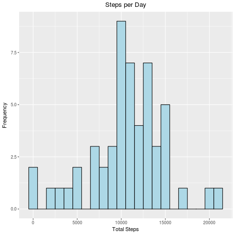

```r
png(filename = "histogram_1.png", width = 480, height = 480, units = "px", pointsize = 12, bg="white")
qplot(stepsPerDay$Steps, binwidth = 1000, geom = "histogram", xlab = "Total Steps",
    ylab = "Frequency", fill=I("lightblue"), col=I("black"), main ="Steps per Day") +
    theme(plot.title = element_text(hjust = 0.5))
dev.off()
```

### Calculate the mean and median of the steps per day

```r
spdmedian <- median(stepsPerDay$Steps)
spdmean <- mean(stepsPerDay$Steps)
spdmedian
```

```
## [1] 10765
```

```r
spdmean
```

```
## [1] 10766.19
```

**Steps Per Day Median**: 10765

**Steps Per day Mean**: 10766.19

## What is the average daily activity pattern?

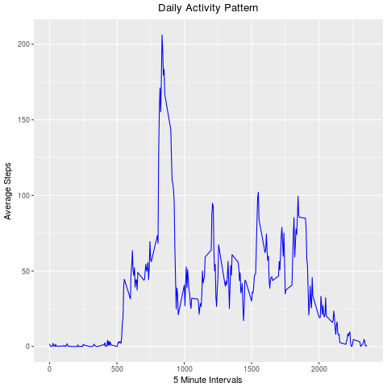

```r
byInterval <- aggregate(x=list(mean_steps = activitiesNoNAs$steps),
    by = list(interval=activitiesNoNAs$interval), mean)

png(filename = "activity_pattern.png", width = 480, height = 480, units = "px", pointsize = 12, bg="white")
ggplot(byInterval, aes(x=interval, y=mean_steps)) + geom_line(color = "blue") +
    xlab("5 Minute Intervals") + ylab("Average Steps") +
    ggtitle("Daily Activity Pattern") + theme(plot.title = element_text(hjust = 0.5))
dev.off()
```

## Imputing missing values

### Calculate the total number of missing values (Steps that are NA)

```r
missingvalues <- length(which(is.na(activities$steps)))
missingvalues
```

```
## [1] 2304
```

**Missing Values**: 2304

### Devise a strategy for filling in the all of the missing values in the dataset

I’ll use the **mice** package to impute the missing values for **steps**. First I’ll take another look at the missing values.

```r
kable(md.pattern(activities),align = "l", row.names = FALSE)
```

| date | interval | steps |  |
| --- | --- | --- | --- |
| 1 | 1 | 1 | 0 |
| 1 | 1 | 0 | 1 |
| 0 | 0 | 2304 | 2304 |

The table verifies that the only missing values are the 2304 **steps**.

[output not shown]

The **pmm** (Predicitive Mean Matching) method provided by the **mice** package should do a reasonable good job of imputing the missing values. It will take a while but should provide better approximations.

### Impute the missing values and extract a filled in dataset

```r
activitiesMids <- mice(data = activities, method = "pmm", maxit = 25, seed = 500)
activitiesComplete <- complete(activitiesMids)
kable(md.pattern(activitiesComplete),align = "l", row.names = FALSE)
```

[output not shown]

| steps | date | interval |  |
| --- | --- | --- | --- |
| 1 | 1 | 1 | 0 |
| 0 | 0 | 0 | 0 |

### Create a histogram of the complete set and report the median and mean

```r
stepsPerDay2 <- aggregate(activitiesComplete$steps, by = list(activitiesComplete$date), sum)
names(stepsPerDay2) <- c("Day", "Steps")
png(filename = "histogram_2.png", width = 480, height = 480, units = "px", pointsize = 12, bg="white")

pcomplete <- qplot(stepsPerDay2$Steps, binwidth = 1000, geom = "histogram", xlab = "Total Steps",
    ylab = "Frequency", fill=I("lightblue"), col=I("black"), main ="Steps per Day (Complete)") +
    theme(plot.title = element_text(hjust = 0.5))

pincomplete <- qplot(stepsPerDay$Steps, binwidth = 1000, geom = "histogram", xlab = "Total Steps",
    ylab = "Frequency", fill=I("lightblue"), col=I("black"), main ="Steps per Day") +
    theme(plot.title = element_text(hjust = 0.5))
grid.arrange(pcomplete,pincomplete, ncol = 2)
dev.off()
```

```r
spdmedian2 <- median(stepsPerDay2$Steps)
spdmean2 <- mean(stepsPerDay2$Steps)
spdmedian2
```

```
## [1] 10600
```

```r
spdmean2
```

```
## [1] 10761.16
```

[figure not shown]

**Steps Per Day Median**: 10600

**Steps Per day Mean**: 10761.16

Both the median and mean changed slightly after imputing the missing values. The distribution looks very similar with some changes caused by imputing the missing values.

## Are there differences in activity patterns between weekdays and weekends?

Create a new factor variable in the dataset with two levels – “weekday” and “weekend” indicating whether a given date is a weekday or weekend day.

```r
activitiesComplete %<>% mutate(date=ymd(date))
activitiesComplete$daytype <- as.factor(ifelse(weekdays(activitiesComplete$date, abbreviate = TRUE)
                                               %in% c("Sat","Sun"), "Weekend","Weekday"))
```

Make a panel plot containing a time series plot (i.e. type = “l”) of the 5-minute interval (x-axis) and the average number of steps taken, averaged across all weekday days or weekend days (y-axis). See the README file in the GitHub repository to see an example of what this plot should look like using simulated data.

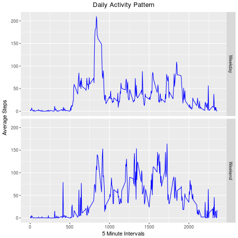

```r
    wwIntervals <- aggregate(x=list(mean_steps = activitiesComplete$steps),
                             by = list(interval=activitiesComplete$interval, weekday=activitiesComplete$daytype), mean)
    png(filename = "weekendVSweekday.png", width = 480, height = 480, units = "px", pointsize = 12, bg="white")
    ggplot(wwIntervals, aes(x=interval, y=mean_steps)) + geom_line(color = "blue") +
        xlab("5 Minute Intervals") + ylab("Average Steps") + ggtitle("Daily Activity Pattern") +
        theme(plot.title = element_text(hjust = 0.5)) + facet_grid(weekday ~ .)
    dev.off()
```